# Make a BGP map Notebook for American Kestrel

C. M. Bossu&Claire Labuda

## Overview

This chronicles the steps taken whilst making a `genoscape` for American Kestrel. The order in which we discuss building up this map is different from the order in which we put layers down to actually make the map. Here, we will start with making the genoscape, which is actually the part that sits atop the whole map. But we do that because that is the part that will actually change from species to species, and we want everyone to be relatively fresh for understanding those mutable parts. Once the genoscape is dealt with, we will then talk about the next layer of country and state boundaries, and also coastline polygons. We do this, because it doesn’t take too long to plot these features, and using them is a good way to figure out the desired extent of your map and to decide upon a projection. Finally, we will talk about the bottom layer of the map, which is the raster with earthforms and shading from Natural Earth Data.

## Packages Needed

### Non-standard Packages

This work draws on a few functions that I have in packages that I have up on GitHub, namely:

1. **Eric Anderson’s fork** of `tess3r`. Note that you can’t use the default version of `tess3r`, you have to use Eric’s fork of it, which has some extra functionality.
2. Eric’s package `genoscapeRtools`

Get those packages like this:

```r
remotes::install_github("eriqande/TESS3_encho_sen")  # for special version of tess3r
remotes::install_github("eriqande/genoscapeRtools")  # for Eric's genoscapeRtools
```

### Standard Packages

The rest of the packages you need can be downloaded from CRAN. If you don’t have them you should get them: `raster`, `sf`, `fields`, `downloader`, and `tidyverse`. The last one there gets ggplot2 and a number of other packages by Hadley Wickham.

You can get those like this:

```r
#install.packages(c("raster", "sf", "tidyverse", "fields", "downloader"))
```

### Load the Packages We will work with

```r
library(raster)  # important to load before tidyverse, otherwise it masks select()
library(tidyverse)
library(sf)
library(ggspatial)
library(scales)
library(terra)
library(tess3r)
library(genoscapeRtools)
library(readr)
library(dplyr)
library(tidyr)
library(openxlsx)
library(writexl)
library(ggplot2)
library(scatterpie)
library(ggforce)
```

## Making the genoscape

The genoscape can be thought of as the bright colors smeared across space that show where different genetically identifiable groups of birds reside on the breeding grounds. These genoscapes are stored as rasters, and transparency is used to indicate how much confidence one has in the genetic identification of individuals in different areas. These rasters are made by interpolating Q-values from a program like STRUCTURE or ADMIXTURE between individuals that were sampled in space.

### Input Data

Normally you would input the ancestry matrix created in STRUCTURE or ADMIXTURE. But since the genoscape was created already (Ruegg et al. 2021), I’m just providing you the raster of the genoscape, with the colors we used to be consistent and you can plot this for your figures.

#### Breeding Bird Lat-Longs

We also need to know where those individuals were sampled in space. We have that here- though use the file I created specifically for the breeding birds.

[output not shown]

[output cut: 17 more lines]

```r
LatLong_tibble
```

#### Breeding Bird Cluster Colors

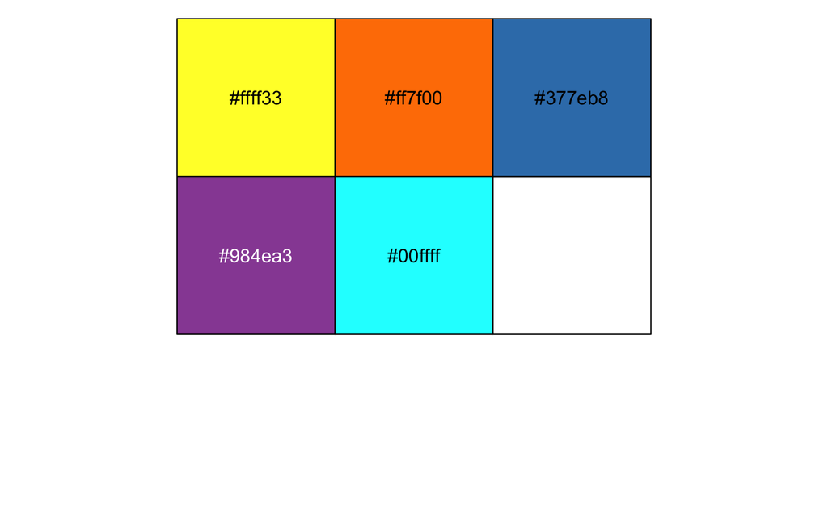

For fun, we can plot these to see what they look like:

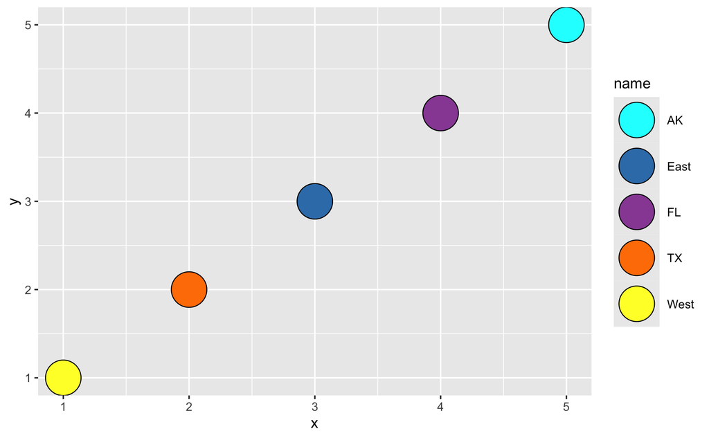

```r
enframe(cluster_colors) %>%
  mutate(x = 1:n(),
         y = 1:n()) %>%
  ggplot(aes(x = x, y = y, fill = name)) +
  geom_point(pch = 21, size = 12) +
  scale_fill_manual(values = cluster_colors)
```

#### Breeding Bird Shapefile

Finally, we need to have a GIS Shapefile that tells us the range of the breeding birds, so that genoscape can be clipped properly. We read this shapefile with the `st_read()` function from package `sf`. American Kestrels have a range that goes into South America, where we do not have sampling, so we crop to North America.

```r
breeding <- st_read("AMKE_shapefiles_rasters/eBird_range/AMKE.range_smooth.sf.WGS84.Ebird.shp") %>% filter(season=="breeding")

#crop<-c(-152.9703,-37.20669,0,68.98193)
breeding_crop <- st_crop(breeding, c(xmin=-152.9703, xmax=-37.20669, ymin=14, ymax=68.98193))
```

For grins, we can plot those polygons to see what they look like.

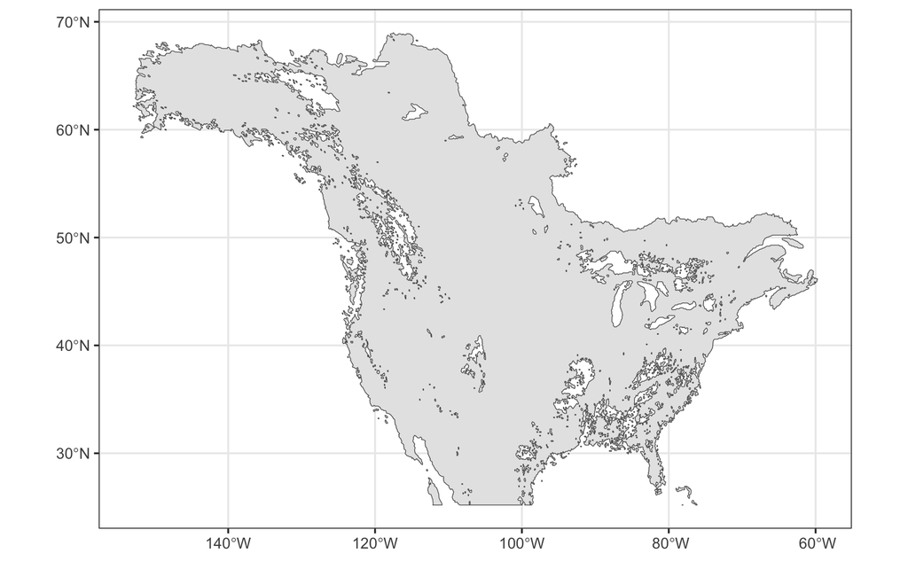

```r
ggplot(breeding_crop) +
  geom_sf() +
  theme_bw()
```

### Preparing the data for tess3Q_map_rasters

Here is the raster of the AMKE genoscape. Read it in, and name the layers so they match with the color assignment above.

```r
genoscape_brick1 <- stack("AMKE_shapefiles_rasters/AMKE_crop.genoscape_brick.tif")
crs(genoscape_brick1) <- "EPSG:4326"
summary(genoscape_brick1)
```

```
        AMKE_crop.genoscape_brick_1 AMKE_crop.genoscape_brick_2
Min.                   5.654572e-02               -7.106473e-02
1st Qu.                2.097741e-01                3.065377e-02
Median                 3.863499e-01                5.146844e-02
3rd Qu.                5.083712e-01                8.166010e-02
Max.                   6.694157e-01                7.706127e-01
NA's                   5.577200e+04                5.577200e+04
        AMKE_crop.genoscape_brick_3 AMKE_crop.genoscape_brick_4
Min.                  -4.068908e-02               -3.365466e-02
1st Qu.                1.656859e-01                4.451256e-02
Median                 2.476421e-01                7.119361e-02
3rd Qu.                5.376502e-01                9.204463e-02
Max.                   7.359911e-01                5.680302e-01
NA's                   5.577200e+04                5.577200e+04
        AMKE_crop.genoscape_brick_5
Min.                  -6.514715e-02
1st Qu.                6.650596e-02
Median                 9.629189e-02
3rd Qu.                1.495031e-01
Max.                   5.947063e-01
NA's                   5.577200e+04
```

```r
names(genoscape_brick1) <- c("West", "TX", "East", "FL", "AK")
```

That gives us a raster brick of Q-values associated with each cell in the raster, but those values are not always constrained between 0 and 1, so we have to massage them a little bit in the next section.

### Scaling and cleaning the genoscape_brick

For this we use the function `genoscapeRtools::qprob_rando_raster()`. This takes the raster brick that comes out of tess3Q_map_rasters() and does some rescaling and (maybe) some random sampling to return a raster of colors that I hope will do a reliable job of representing (in some way) predicted assignment accuracy over space. See `?genoscapeRtools::qprob_rando_raster` to learn about the scaling options, etc.

This will squash the raster brick down to a single RGBA (i.e., four channels, red, green, blue and alpha) raster brick. You can adjust the alpha (the transparency) by adjusting the alpha_exp parameter. The higher it is, the more transparency there is.

We can easily plot this with the function `layer_spatial` from the `ggspatial` package:

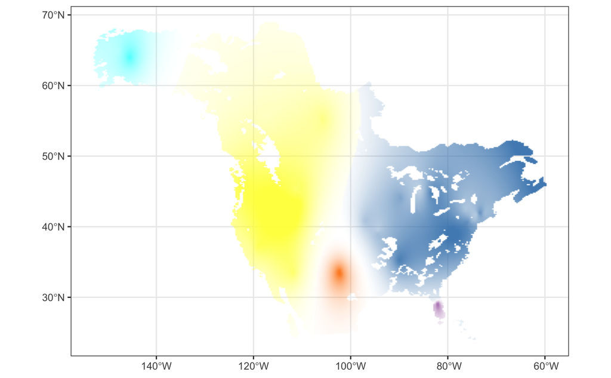

Note that if we wanted to add the actual sampling points to this (that are given in `LatLong_tibble`), we can use ggspatial’s `geom_spatial_point()` function.

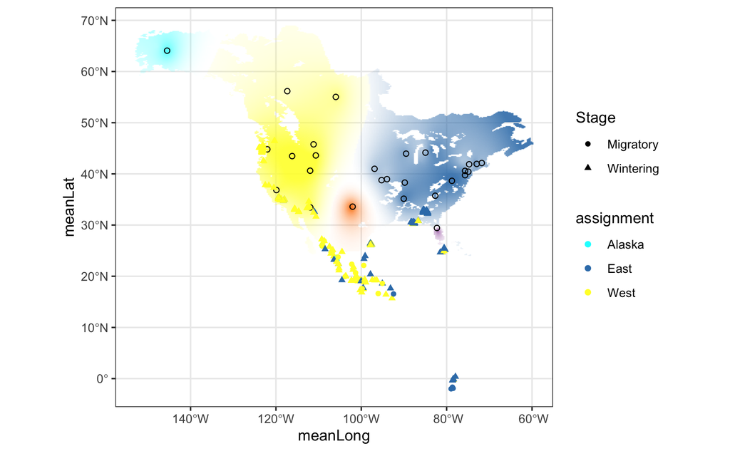

## Coastlines, Countries, States, and Provinces

Since we will be using the Natural Earth Data Set for the raster background of our map, we will also use the Natural Earth lines and polygons. The Natural Earth data set is an amazing, open-source resource for making beautiful maps. Check it out at [naturalearthdata.com](https://www.naturalearthdata.com/).

### Plot the Coastlines and estimate where we want to clip

First read it in directly from website:

```r
coastlines <-  st_read("/vsizip//vsicurl/https://naciscdn.org/naturalearth/10m/physical/ne_10m_coastline.zip/ne_10m_coastline.shp")
```

Now, let’s just crop out the part that we want. This is somewhat key: right here we will define the extent in lat-long of the region that we want to plot… You should match this to the previous tutorial.

```r
# note! it is important to put the elements of domain in this
# order, because the function raster::extent() is expecting thing to be in this order, and doesn't parse the names of the vectors
# the way sf::st_crop() does.
sf_use_s2(FALSE)
domain <- c(
  xmin = -180,
  xmax = -40,
  ymin = -50,
  ymax = 82
)

coast_cropped <- st_crop(coastlines, domain)
```

Then plot the cropped part:

```r
ggplot(coast_cropped) +
  geom_sf() +
  coord_sf()
```

[output not shown]

### All the lines, plus the genoscape

OK, that was pretty reasonable. Now crop all the stae and country lines to `domain` and plot them, and put the genoscape on top of that, too.

```r
countries_cropped <- st_read("/vsizip//vsicurl/https://naciscdn.org/naturalearth/10m/cultural/ne_10m_admin_0_countries.zip/ne_10m_admin_0_countries.shp") %>%
  st_crop(domain)
states_cropped    <- st_read("/vsizip//vsicurl/https://naciscdn.org/naturalearth/10m/cultural/ne_10m_admin_1_states_provinces.zip/ne_10m_admin_1_states_provinces.shp") %>%
  st_crop(domain)
```

Now, plot it all. Notice we do it by just adding layers.

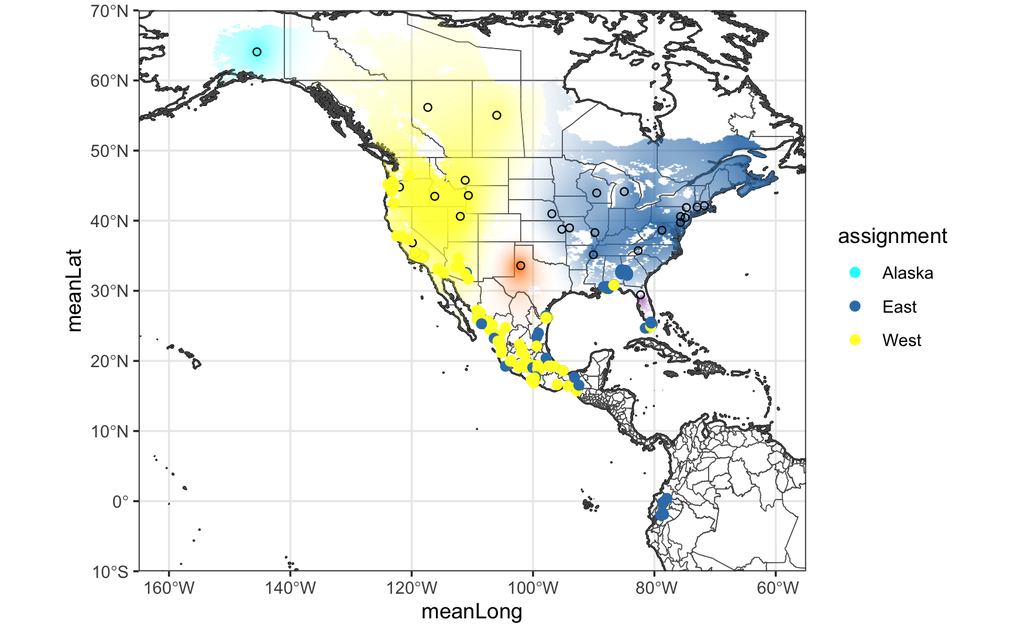

That is looking like it should, but the projection is pretty ugly. In the next section we will consider projection.

## Projecting

The new version of `ggplot2` makes it super easy to project everything on the fly by passing the projection to `coord_sf()`. For things in North America, it seems that a Lambert conic projection does a nice job of keeping British Columbia and Alaska from looking way too big. We can define such a projection with a string, like this:

```r
lamproj <- "+proj=lcc +lat_1=20 +lat_2=60 +lat_0=40 +lon_0=-100 +x_0=0 +y_0=0 +ellps=GRS80 +datum=NAD83 +units=m +no_defs"
```

Now, let’s see how our developing map looks under such a projection. We just define `lamproj` as a coordinate reference system and pass it in to `coord_sf()`:

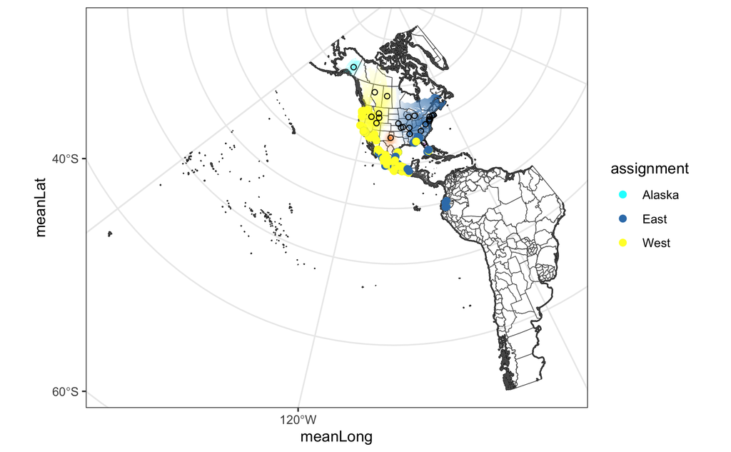

I would call that decidedly better with the projection.

## The pretty-map background

Now, all that remains is to put all of this on top of a nicely tinted map that shows landforms and things. Note that once we have such a layer under the rest of this stuff, we will probably omit the coastline layer, since it gets a little dark where the coastline is highly dissected.

### Downloading Natural Earth rasters

I am going to recommend that you get the hypsometrically tinted Natural Earth map with water bodies and rivers on it, and you might as well get the one that has some ocean basin coloring too. We will put it into a directory in the project called `ne_rasters`. Note, this expands to about half a gig of data.

```r
name <- "HYP_HR_SR_OB_DR"            # or "HYP_HR_SR_W_DR" for full resolution
url  <- sprintf("https://naciscdn.org/naturalearth/10m/raster/%s.zip", name)

options(timeout = 3600)             # large file; the default 60 s will time out
download.file(url, paste0(name, ".zip"), mode = "wb")
unzip(paste0(name, ".zip"), exdir = name)
```

## Clipping a rectangle out of that

I’ve done this already, so easy peasy for you. Let’s plot this below. Note it will take a bit!

```
|---------|---------|---------|---------|
=========================================
```

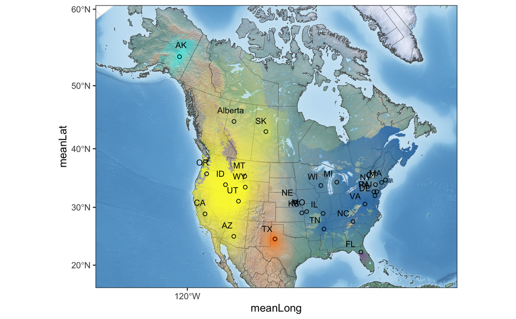

```r
rectangled <- ggplot() +
  ggspatial::layer_spatial(hypso_bg_cropped) +
  geom_sf(data = countries_cropped, fill = NA, size = 0.15) +
  geom_sf(data = states_cropped, fill = NA, size = 0.1) +
  ggspatial::layer_spatial(genoscape_rgba) +
  geom_spatial_point(data = LatLong_tibble, mapping = aes(x = meanLong, y = meanLat),shape=1) +
#  geom_spatial_point(data = Rub_certain, mapping = aes(x = Long, y = Lat, col=assignment),size=2)+
  scale_colour_manual(values=c("cyan","#377eb8","#ffff33")) +
  geom_spatial_text(data = LatLong_tibble, mapping = aes(x = meanLong-2, y = meanLat+2,label=State),size=3) +
  theme_bw() +
  coord_sf(
    crs = st_crs(lamproj),
    xlim = c(-3968118, 3671262),
    ylim = c(-1699797, 4264362),
    expand = FALSE)  # expand = FALSE means put the axes right at the xlim and ylim

rectangled
```

Okay, that does it. In reality, you would probably want to expand the original `domain` to be a bigger chunk of the earth, so that when you cut stuff off there was more left…

## A final note

If you want to add more elements to the figure you can do so by giving them a lat-long and making a simple features tibble out of it and then putting them there using geom_sf(). It all fits nicely into the ggplot framework.

# creates genoscape with points

[output not shown]

```r
winter_birds_gen %>% group_by(assignment) %>% tally()
```

# Read in ecoregions and add abbreviations

```r
ecoregions <- st_read("AMKE_shapefiles_rasters/winter_ecoregion/AMKE.winterEcoregions.simple.sf.WGS84.noWater.Ebird.shp")
ecoregions <- ecoregions %>%
  mutate(node = case_when(
        Region == "Highland/Interior Mexico" ~ "HIM",
    Region == "Highland Central America" ~ "HCA",
    Region == "Lowland Central America" ~ "LCA",
    Region == "Atlantic Lowland Mexico" ~ "ALM",
    Region == "Northwest Mexico" ~ "NWM",
    Region == "Southwest Mexico" ~ "SWM",
    Region == "Northern Andes" ~ "NAndes",
    Region == "Amazon/Orinoco-Northern Uplands" ~ "AONU",
    Region == "Caribbean" ~ "CAR",
    Region == "California" ~ "CAL",
    Region == "Southcentral US" ~ "SCUS",
    Region == "Southeastern US" ~ "SEUS",
    Region == "Marine West Coast Forests" ~ "MWCF",
    Region == "Northwestern Forested Mountains" ~ "NFM",
    TRUE ~ Region
  ))
centroids <- cbind(
  ecoregions,
  st_coordinates(st_centroid(ecoregions))
)
```

```r
ggsave("output/Rubias/AMKE.genetic_sampling.assignment.pretty_map.lamproj.Panel2.pdf")
```

```
|---------|---------|---------|---------|
=========================================
```

##CREATES PIECHARTS based on ecoregions: too broad

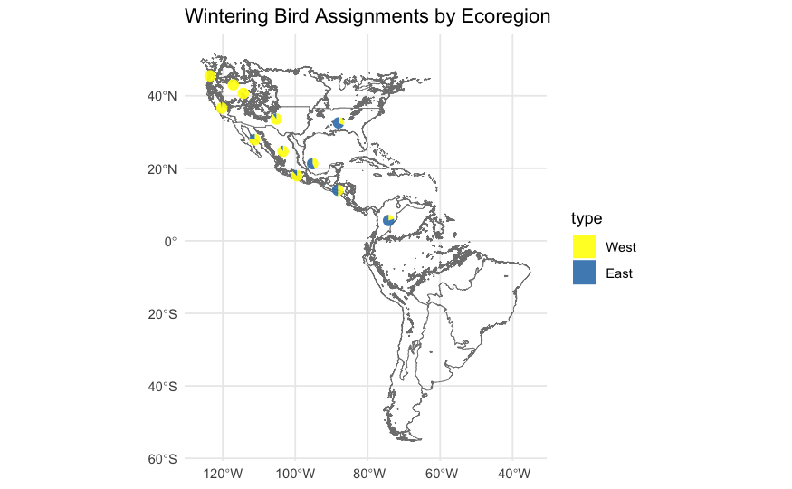

#Creates piecharts based off of grid

[output not shown]

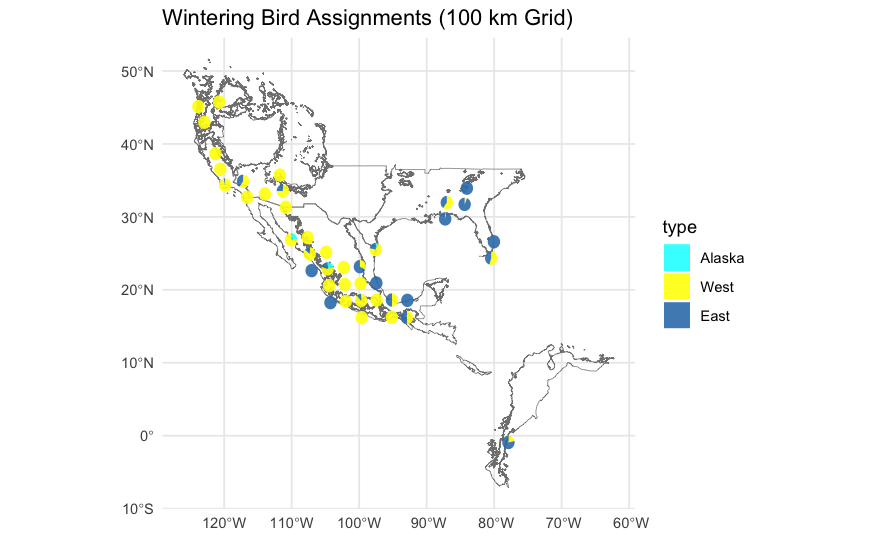

#PIES WITH NICE BACKGROUND

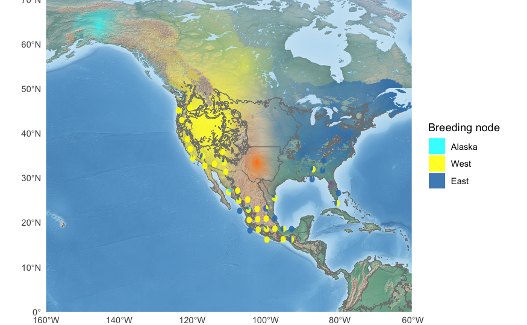

#Creates FULL GENOSCAPE

```r
# Define all 5 breeding populations and colors
breeding_colors <- c(
  "Alaska" = "cyan",
  "West" = "yellow",
  "East" = "#377eb8",
  "TX" = "orange",
  "FL" = "purple"
)

# Build the map
ggplot() +
  # Bottom layer: hypso background
  ggspatial::layer_spatial(hypso_bg) +
  # Middle layer: genoscape raster (with transparency)
  ggspatial::layer_spatial(genoscape_rgba, alpha = 1.1) +
  # Vector outlines for ecoregions
  geom_sf(data = ecoregions, fill = NA, color = "gray50") +
  # Scatterpie for wintering birds (only actual data)
  geom_scatterpie(
    aes(x = X, y = Y, group = grid_id),
    data = filt_pies,
    cols = c("Alaska", "West", "East"), # only the populations present
    color = NA,
    alpha = .9,
    pie_scale = .8
  ) +
  # Manual legend added via invisible points
  geom_point(
    data = data.frame(
      pop = names(breeding_colors),
      x = NA, y = NA  # not plotted on the map
    ),
    aes(x = x, y = y, fill = pop),
    shape = 21,
    size = 5,
    show.legend = TRUE
  ) +
  scale_fill_manual(
    values = breeding_colors,
    name = "Breeding Population"
  ) +
  # Coordinate system
  coord_sf(
    crs = st_crs(4326),
    xlim = c(-160, -60),
    ylim = c(0, 70),
    expand = FALSE
  ) +
  theme_minimal() +
  theme(
    plot.margin = unit(c(0,0,0,0), "cm"),
    legend.position = "right"
  )
```

[output not shown]

#Adds labels to ecoregions

```r
# --- Step 1: Add abbreviations to your ecoregions ---
ecoregions <- ecoregions %>%
  mutate(node = case_when(
        Region == "Highland/Interior Mexico" ~ "HIM",
    Region == "Highland Central America" ~ "HCA",
    Region == "Lowland Central America" ~ "LCA",
    Region == "Atlantic Lowland Mexico" ~ "ALM",
    Region == "Northwest Mexico" ~ "NWM",
    Region == "Southwest Mexico" ~ "SWM",
    Region == "Northern Andes" ~ "NAndes",
    Region == "Amazon/Orinoco-Northern Uplands" ~ "AONU",
    Region == "Caribbean" ~ "CAR",
    Region == "California" ~ "CAL",
    Region == "Southcentral US" ~ "SCUS",
    Region == "Southeastern US" ~ "SEUS",
    Region == "Marine West Coast Forests" ~ "MWCF",
    Region == "Northwestern Forested Mountains" ~ "NFM",
    TRUE ~ Region
  ))

# --- Step 2: Compute centroids for labeling ---
ecoregion_centroids <- cbind(
  ecoregions,
  st_coordinates(st_centroid(ecoregions))
)

# --- Step 3: Define breeding colors ---
breeding_colors <- c(
  "Alaska" = "cyan",
  "West" = "yellow",
  "East" = "#377eb8",
  "TX" = "orange",
  "FL" = "purple"
)

# --- Step 4: Build the map ---
final_map <- ggplot() +
  # Bottom layer: hypso background
  ggspatial::layer_spatial(hypso_bg) +

  # Genoscape raster
  ggspatial::layer_spatial(genoscape_rgba, alpha = 1.1) +

  # Ecoregion outlines
  geom_sf(data = ecoregions, fill = NA, color = "gray50") +

  # Scatterpie for wintering birds
  geom_scatterpie(
    aes(x = X, y = Y, group = grid_id),
    data = filt_pies,
    cols = c("AK", "West", "East"),
    color = NA,
    alpha = 0.9,
    pie_scale = .8
  ) +

  geom_text(
  data = filt_pies,
  aes(x = X, y = Y, label = n),
  size = 1.8,
  color = "gray"
) +

  # Ecoregion labels
  geom_text(
    data = centroids_filtered,
    aes(x = X, y = Y, label = node),
    size = 2,
    color = "black"
  ) +

  # Manual legend for breeding populations
  geom_point(
    data = data.frame(
      pop = names(breeding_colors),
      x = NA, y = NA
    ),
    aes(x = x, y = y, fill = pop),
    shape = 21,
    size = 5,
    show.legend = TRUE
  ) +
  scale_fill_manual(
    values = breeding_colors,
    name = "Breeding Population"
  ) +

  # Coordinate system
  coord_sf(
    crs = st_crs(4326),
    xlim = c(-160, -60),
    ylim = c(0, 70),
    expand = FALSE
  ) +
  theme_minimal() +
  theme(
    plot.margin = unit(c(0,0,0,0), "cm"),
    legend.position = "right"
  )

# --- Step 5: Plot ---
final_map

#ggsave("~/Downloads/genoscape_piechart_with_FL_MWCF_ecoregions.pdf", final_map, width = 10, height = 8)
```

[output not shown]

#Genoscape with banding and genetic data

```r
##banding data
banding_data <- read_delim("input/MigConn/AMKEbandingrecoverymatri")


banding_data <- banding_data %>%
  rename(
    latitude = winter_lat,
    longitude = winter_long
  )

banding_sf <- st_as_sf(
  banding_data,
  coords = c("longitude", "latitude"),
  crs = 4326
)
banding_sf <- banding_sf %>%
  mutate(
    assignment = Cluster,
    stage_clean = "Banding"
  )
banding_sf$source <- "Banding"


# --- Load data ---
winter_birds <- read_delim("~/genetics_certain1.txt", delim = "\t")

winter_birds <- winter_birds %>%
  mutate(stage_clean = case_when(
    is.na(Stage) ~ "Wintering",
    Stage %in% c("Winter", "Wintering") ~ "Wintering",
    Stage %in% c("Migr", "Migrating") ~ "Migrating",
    TRUE ~ "Wintering"
  ))

winter_birds <- winter_birds %>%
  rename(
    latitude = Lat,
    longitude = Long
  )

# --- Load ecoregions ---
ecoregion <- st_read("~/Downloads/winter_ecoregion 2/AMKE.winterEcoregions.simple.sf.WGS84.noWater.Ebird.shp") %>%
  mutate(node = case_when(
    Region == "North American Deserts" ~ "NAD",
    Region == "Great Plains" ~ "GP",
    Region == "Eastern Temperate Forests" ~ "ETF",
    Region == "Northwestern Forested Mountains" ~ "NWFM",
    Region == "Marine West Coast Forests" ~ "MWCF",
    Region == "Highland/Interior Mexico" ~ "HIM",
    Region == "Highland Central America" ~ "HCA",
    Region == "Northwest Mexico" ~ "NWM",
    Region == "Atlantic Lowland Mexico" ~ "ALM",
    Region == "California" ~ "CAL",
    Region == "Southcentral US" ~ "SCUS",
    Region == "Southeastern US" ~ "SEUS",
    Region == "Southwest Mexico" ~ "SWM",
    Region == "Northern Andes" ~ "NAndes",
    TRUE ~ NA_character_
  )) %>%
  filter(!is.na(node))
centroids <- cbind(
  ecoregion,
  st_coordinates(st_centroid(ecoregion))
)

# --- Centroids for labels ---
centroids <- cbind(
  ecoregions,
  st_coordinates(st_centroid(ecoregions))
)

# --- Colors ---
winter_colors <- c(
  "AK" = "cyan",
  "West" = "yellow",
  "East" = "dodgerblue",
  "FL" = "purple",
  "TX" = "orange"
)
#jitter points
# Convert to sf (WGS84)
winter_sf <- st_as_sf(
  winter_birds,
  coords = c("longitude", "latitude"),
  crs = 4326
)

# Project to lambert (same CRS you used before)
winter_sf_proj <- st_transform(winter_sf, crs = lamproj)

# Extract coordinates
coords <- st_coordinates(winter_sf_proj)

# Apply jitter (~70 km like your original)
coords[,1] <- coords[,1] + rnorm(nrow(coords), 0, 50000)
coords[,2] <- coords[,2] + rnorm(nrow(coords), 0, 50000)

# Put jittered coords back into sf object
winter_sf_proj$geometry <- st_as_sf(
  data.frame(coords),
  coords = c("X", "Y"),
  crs = lamproj
)$geometry

# Transform BACK to WGS84 for raster compatibility
winter_sf_final <- st_transform(winter_sf_proj, 4326)
winter_sf_final$source <- "Genetics"
combined_sf <- bind_rows(winter_sf_final, banding_sf)

# =========================================================
# ️ FINAL MAP
# =========================================================
#to plot alaska on top
ak_points <- winter_sf_final %>% filter(assignment == "AK")
other_points <- winter_sf_final %>% filter(assignment != "AK")

winter_map <- ggplot() +

  # --- Background (same as pie chart map) ---
  ggspatial::layer_spatial(rast("~/winter_background_extended.tif")) +
  ggspatial::layer_spatial(genoscape_rgba, alpha = 1.1) +

  # --- Ecoregions ---
  geom_sf(
    data = ecoregions,
    fill = NA,
    color = "gray50",
    size = 0.2
  ) +

  # --- JITTERED POINTS ---
# Other points first
geom_sf(
  data = combined_sf,
  aes(fill = assignment, shape = stage_clean),
  color = "black",
  stroke = 0.2,
  size = 2.7,
  alpha = 0.8
) +

# Alaska points LAST (on top)
geom_sf(
  data = ak_points,
  aes(fill = assignment, shape = stage_clean),
  color = "black",
  stroke = 0.2,
  size = 2.7,
  alpha = 0.9
) +


  # --- Labels ---
  geom_text(
    data = centroids_filtered,
    aes(x = X, y = Y, label = node),
    size = 3
  ) +

  scale_fill_manual(values = winter_colors) +

  scale_shape_manual(
  values = c(
    "Wintering" = 21,  # circle
    "Migrating" = 24, # triangle
    "Banding" = 22
  ),
  name = "Stage"
)+

  # --- Match pie chart map extent ---
  coord_sf(
    crs = st_crs(4326),
    xlim = c(-160, -60),
    ylim = c(-5, 70),
    expand = FALSE
  ) +

  theme_minimal() +
  theme(
    plot.margin = unit(c(0,0,0,0), "cm"),
    legend.position = "right"
  ) +

scale_fill_manual(
  values = winter_colors,
  name = "Breeding Assignment"
) +

guides(
  fill = guide_legend(
    override.aes = list(shape = 21, color = "black")
  ),
  shape = guide_legend(
    override.aes = list(fill = "black", color = "black")
  )
)
# --- Plot ---
winter_map

ggsave("~/Downloads/combinedgenoscape.pdf",
       winter_map,
       width = 10,
       height = 8)
```

[output not shown]

# BUILD PIES FROM COMBINED DATA (GENETICS + BANDING)

```r
# --- extract coordinates ---
combined_sf <- combined_sf %>%
  mutate(
    X = st_coordinates(.)[,1],
    Y = st_coordinates(.)[,2]
  )

grid <- st_make_grid(combined_sf, cellsize = 1.5)

grid_sf <- st_sf(
  grid_id = 1:length(grid),
  geometry = grid
)

# --- assign to existing grid ---
combined_with_grid <- st_join(combined_sf, grid_sf)

# ---count individuals per cluster per grid ---
pie_data_combined <- combined_with_grid %>%
  st_drop_geometry() %>%
  group_by(grid_id, assignment) %>%
  summarise(n = n(), .groups = "drop")

# --- wide format for scatterpie ---
pie_wide_combined <- pie_data_combined %>%
  pivot_wider(
    names_from = assignment,
    values_from = n,
    values_fill = 0
  )

# --- total count per grid ---
pie_wide_combined <- pie_wide_combined %>%
mutate(
  n = rowSums(across(c(AK, West, East, TX, FL)), na.rm = TRUE)
)

# ---  filter small samples (same rule as before) ---
filt_pies_combined <- pie_wide_combined %>%
  filter(n >= 3)

# --- attach coordinates from your existing grid centroids ---
coords_df <- grid_sf %>%
  st_centroid() %>%
  mutate(
    X = st_coordinates(.)[,1],
    Y = st_coordinates(.)[,2]
  ) %>%
  st_drop_geometry() %>%
  dplyr::select(grid_id, X, Y)

filt_pies_combined <- filt_pies_combined %>%
  left_join(coords_df, by = "grid_id")


#plotting
# ---  Added abbreviations to ecoregions previously ---

# --- Compute centroids for labeling ---
ecoregion_centroids <- cbind(
  ecoregions,
  st_coordinates(st_centroid(ecoregions))
)

filt_pies_north <- filt_pies_combined %>%
  filter(Y >= 10)

filt_pies_south <- filt_pies_combined %>%
  filter(Y < 10)

south_pie <- filt_pies_south %>%
  summarise(
    AK = sum(AK, na.rm = TRUE),
    West = sum(West, na.rm = TRUE),
    East = sum(East, na.rm = TRUE),
    TX = sum(TX, na.rm = TRUE),
    FL = sum(FL, na.rm = TRUE)
  ) %>%
  mutate(
    n = AK + West + East + TX + FL,
    X = mean(filt_pies_south$X, na.rm = TRUE),   # center it
    Y = 2   #place it slightly above cutoff so it's visible
  )

filt_pies_final <- bind_rows(
  filt_pies_north,
  south_pie
)

# --- Define breeding colors ---
breeding_colors <- c(
  "AK" = "cyan",
  "West" = "yellow",
  "East" = "dodgerblue",
  "TX" = "orange",
  "FL" = "purple"
)

# ---  Build the map ---
final_map <- ggplot() +
  # Bottom layer: hypso background
  ggspatial::layer_spatial(hypso_bg) +

  # Genoscape raster
  ggspatial::layer_spatial(genoscape_rgba, alpha = 1.1) +

  # Ecoregion outlines
  geom_sf(data = ecoregions, fill = NA, color = "gray50") +

  # Scatterpie for wintering birds
  geom_scatterpie(
    aes(x = X, y = Y, group = grid_id),
    data = filt_pies_final,
    cols = c("AK", "West", "East", "FL", "TX"),
    color = NA,
    alpha = 0.9,
    pie_scale = .8
  ) +

  geom_text(
  data = filt_pies_final,
  aes(x = X, y = Y, label = n),
  size = 1.8,
  color = "gray"
) +

  # Ecoregion labels
  geom_text(
    data = centroids_filtered,
    aes(x = X, y = Y, label = node),
    size = 2,
    color = "black"
  ) +

  # Manual legend for breeding populations
  geom_point(
    data = data.frame(
      pop = names(breeding_colors),
      x = NA, y = NA
    ),
    aes(x = x, y = y, fill = pop),
    shape = 21,
    size = 5,
    show.legend = TRUE
  ) +
  scale_fill_manual(
    values = breeding_colors,
    name = "Breeding Population"
  ) +

  # Coordinate system
  coord_sf(
    crs = st_crs(4326),
    xlim = c(-160, -60),
    ylim = c(0, 70),
    expand = FALSE
  ) +
  theme_minimal() +
  theme(
    plot.margin = unit(c(0,0,0,0), "cm"),
    legend.position = "right"
  )

# ---  Plot ---
final_map

ggsave("~/Downloads/combinedpiechartgenoscape.pdf",
       final_map,
       width = 10,
       height = 8)
```

[output not shown]